# Portfolio Optimization

Portfolio Optimization Yarka Lyba, Yevheniya Mitriahina April, 2019

## Abstract

Modern portfolio theory is a concept from finance to describe ways of diversifying and allocating assets in a finacial portfolio in order to maximize the porfolios expected return given some level of risk tolerance. Using modern portfolio theory an investor bundels different types of investments together, so that when some of the securities fall in value other rise. So in that case the return of each individual asset is less important then the behaviour of the entire portfolio. American economist `Harry Markowitz` first introduced Modern portfolio theory in 1952 what led to him being awarded the Nobel Prize in Economics in 1990. Since that time many researchers have developed theories on portfolio optimization and risk management. Aim of this work is to implement some of the approaches and to compare them.

## Monte Carlo simulation

`Monte Carlo Simulation` is a mathematical technique that generates random variables for modelling risk or uncertainty of a certain system. Monte Carlo simulation is often used in finance, engineering and physics. Monte Carlo simulation produces distributions of possible outcome values. This is the easiest way of portfolio optimization, so we will start with it. In our case we use uniform distribution. All values have equal chanses to occur. We define minimum and maximum as 0 and 1.

We use trade data from [Yahoo Finance](https://finance.yahoo.com/). We have selected three companies to work with. That are Facebook, Amazon and Tesla(because it is favourite company of our teacher).

```r
first.date <- Sys.Date() - 360
last.date <- Sys.Date()
freq.data <- 'daily'
tickers <- c('TSLA','FB','AMZN')
l.out <- BatchGetSymbols(tickers = tickers,
                         first.date = first.date,
                         last.date = last.date,
                         freq.data = freq.data)
```

```
##
## Running BatchGetSymbols for:
##    tickers = TSLA, FB, AMZN
## TSLA | yahoo (1|3) | Found cache file - Got 100% of valid prices | Looking good!
## FB | yahoo (2|3) | Found cache file - Got 100% of valid prices | Nice!
## AMZN | yahoo (3|3) | Found cache file - Got 100% of valid prices | You got it!
```

To make it easier to work with data we combine close prices of each company into a table.

```r
#Data manipulation to isolate data from different stocks
tsla <- l.out$df.tickers[which(l.out$df.tickers$ticker == 'TSLA'),][,c(4)]
fb <- l.out$df.tickers[which(l.out$df.tickers$ticker == 'FB'),][,c(4)]
amzn <- l.out$df.tickers[which(l.out$df.tickers$ticker == 'AMZN'),][,c(4)]
date <- l.out$df.tickers[which(l.out$df.tickers$ticker == 'AMZN'),][,c(7)]
#Portfolio
pfl <- cbind.data.frame(date, fb, tsla , amzn)
knitr::kable(head(pfl, 10))
```

| date | fb | tsla | amzn |
| --- | --- | --- | --- |
| 2018-05-10 | 185.53 | 305.02 | 1609.08 |
| 2018-05-11 | 186.99 | 301.06 | 1602.91 |
| 2018-05-14 | 186.64 | 291.97 | 1601.54 |
| 2018-05-15 | 184.32 | 284.18 | 1576.12 |
| 2018-05-16 | 183.20 | 286.48 | 1587.28 |
| 2018-05-17 | 183.76 | 284.54 | 1581.76 |
| 2018-05-18 | 182.68 | 276.82 | 1574.37 |
| 2018-05-21 | 184.49 | 284.49 | 1585.46 |
| 2018-05-22 | 183.80 | 275.01 | 1581.40 |
| 2018-05-23 | 186.90 | 279.07 | 1601.86 |

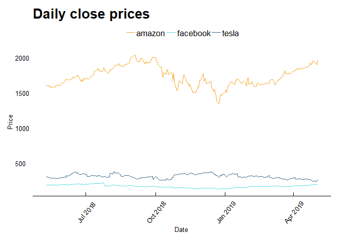

The next step is to calculate daily returns of the stocks.

```r
out_fb <- change(pfl, Var = 'fb',
         type = 'proportion',
         NewVar = 'fb_return',
         slideBy = -1)
out_tsla <- change(out_fb, Var = 'tsla',
         type = 'proportion',
         NewVar = 'tsla_return',
         slideBy = -1)
out_amzn <- change(out_tsla, Var = 'amzn',
         type = 'proportion',
         NewVar = 'amzn_return',
         slideBy = -1)

fb <- out_amzn$fb_return
amzn <- out_amzn$amzn_return
tsla <- out_tsla$tsla_return

returns_daily <- cbind.data.frame(fb, tsla, amzn)
returns_daily <- returns_daily[-1,]
returns_annualy <- cbind(mean(returns_daily$fb[-1])*250, mean(returns_daily$amzn[-1])*250, mean(returns_daily$tsla[-1])*250)

knitr::kable(head(returns_daily, 10))
```

|  | fb | tsla | amzn |
| --- | --- | --- | --- |
| 2 | 0.0078694 | -0.0129827 | -0.0038344 |
| 3 | -0.0018718 | -0.0301933 | -0.0008547 |
| 4 | -0.0124303 | -0.0266809 | -0.0158723 |
| 5 | -0.0060764 | 0.0080935 | 0.0070807 |
| 6 | 0.0030568 | -0.0067719 | -0.0034777 |
| 7 | -0.0058772 | -0.0271315 | -0.0046720 |
| 8 | 0.0099081 | 0.0277075 | 0.0070441 |
| 9 | -0.0037401 | -0.0333227 | -0.0025607 |
| 10 | 0.0168661 | 0.0147631 | 0.0129379 |
| 11 | -0.0051899 | -0.0043717 | 0.0007553 |

From the graph Tesla assets seem to be the riskiest and Amazon assets are fluctuating the least.

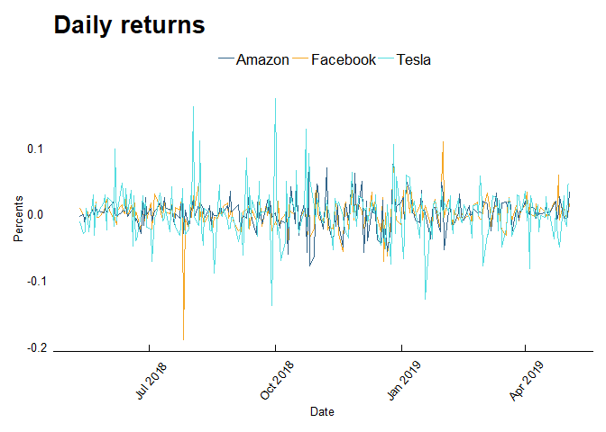

We make our simulations 2000 times. Each time different weights(that sum to one) are generated. Based on those weights return, volatility and sharpe ratio of portfolio is calculated. Sharpe ratio is a measure of risk-adjusted return. We store all the combinations of weights.

```r
cov_daily <- cov(returns_daily, y = returns_daily, use="all.obs")
cov_annualy <- cov_daily*9
cov_annualy
```

```
##               fb        tsla        amzn
## fb   0.004908503 0.001448341 0.002698014
## tsla 0.001448341 0.012672809 0.002008587
## amzn 0.002698014 0.002008587 0.004348402
```

```r
num_assets <- length(tickers)
num_portfolios <- 2000

portfolios <- data.frame(matrix(NA, nrow=num_portfolios, ncol=7))

for (port in 1:num_portfolios) {
  weights <- runif(n = num_assets, min = 0, max = 1)
  weights <- weights/sum(weights)
  returns <- dot(weights, returns_annualy)
  volatility <- sqrt(dot(t(weights), dot(cov_annualy, weights)))
  sharpe = returns/volatility
  portfolios[port,] <- c(port, returns, volatility, sharpe, weights)
  }
colnames(portfolios) <- c('n_port', 'return', 'volatility', 'sharpe', 'fb', 'tsla', 'amzn')

knitr::kable(head(portfolios, 10))
```

| n_port | return | volatility | sharpe | fb | tsla | amzn |
| --- | --- | --- | --- | --- | --- | --- |
| 1 | 0.1108483 | 0.0612832 | 1.8087867 | 0.2230243 | 0.3104139 | 0.4665618 |
| 2 | 0.1031031 | 0.0645780 | 1.5965658 | 0.0586410 | 0.3505118 | 0.5908472 |
| 3 | 0.1404848 | 0.0682723 | 2.0577144 | 0.1466571 | 0.4557114 | 0.3976315 |
| 4 | 0.0986312 | 0.0592286 | 1.6652623 | 0.5768823 | 0.1139886 | 0.3091291 |
| 5 | 0.2021424 | 0.0820018 | 2.4650981 | 0.2152153 | 0.6616755 | 0.1231092 |
| 6 | 0.1111361 | 0.0607931 | 1.8281025 | 0.2495684 | 0.3002692 | 0.4501623 |
| 7 | 0.1423950 | 0.0698436 | 2.0387696 | 0.1114668 | 0.4778951 | 0.4106381 |
| 8 | 0.1276430 | 0.0660870 | 1.9314393 | 0.1360944 | 0.4112401 | 0.4526655 |
| 9 | 0.1345409 | 0.0609041 | 2.2090609 | 0.4681172 | 0.2969161 | 0.2349668 |
| 10 | 0.0562508 | 0.0602698 | 0.9333163 | 0.1243254 | 0.1441230 | 0.7315517 |

Out of all the portfolious we choose one with the smallest volatility. Volatility is a statistical measure of the dispersion of returns for a given security or market index. In most cases, the higher the volatility, the riskier the security.

```r
min_var <- portfolios[portfolios$volatility == min(portfolios$volatility),]
min_var
```

```
##     n_port     return volatility   sharpe        fb      tsla      amzn
## 981    981 0.08798982 0.05802413 1.516435 0.3926196 0.1514672 0.4559132
```

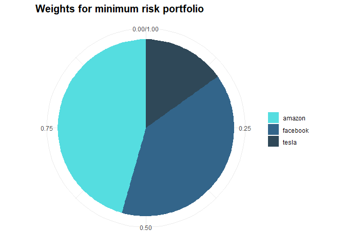

We also look for portfolio with biggest sharpe ratio.

```r
max_sharpe <- portfolios[portfolios$sharpe == max(portfolios$sharpe),]
max_sharpe
```

```
##      n_port    return volatility   sharpe        fb      tsla         amzn
## 1659   1659 0.1956209 0.07316587 2.673664 0.4705158 0.5286982 0.0007860133
```

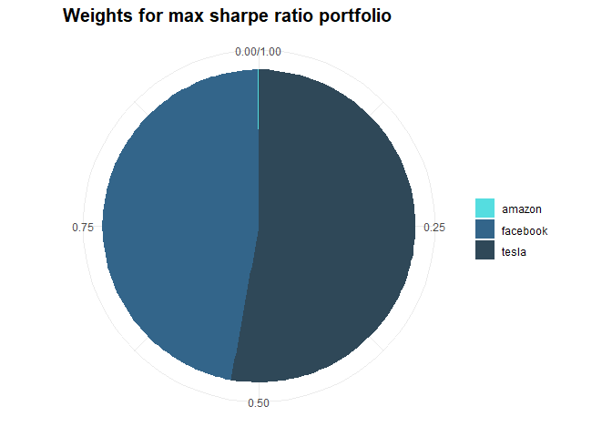

We can plot all the portfolios. They construct efficient frontier. The efficient frontier is the set of optimal portfolios that offer the highest expected return for a defined level of risk or the lowest risk for a given level of expected return. Portfolios that lie below the efficient frontier are sub-optimal because they do not provide enough return for the level of risk.

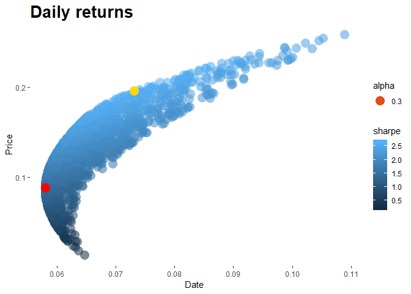

```r
ggplot(portfolios, aes(x=volatility, y=return, color=sharpe, alpha = .3)) +
  geom_point(shape = 16, size = 5) +
  geom_point(aes(x=max_sharpe$volatility, y=max_sharpe$return), colour="gold", shape = 16, size = 5) +
  geom_point(aes(x=min_var$volatility, y=min_var$return), colour="red", shape = 16, size = 5) +
  ggtitle("Daily returns") +
  theme(legend.background = element_rect(fill="transparent"),
        legend.key = element_rect(colour = "transparent", fill = "transparent"),
        plot.title = element_text(size=20, lineheight=.8, vjust=1, family ="Bauhaus 93", face='bold'),
        plot.background = element_rect(fill='transparent'), panel.background = element_rect(fill='transparent')) +
  labs(x="Date", y="Price")
```

## Genetic Algorithm

Genetic algorithm reflects the process of natural selection where the fittest individuals are selected for reproduction in order to produce offspring of the next generation.

For this example we will use more companies that are traded on Nasdaq.

```r
library(BatchGetSymbols)
# Set test period
duration <- 365
first.date <- Sys.Date() - duration
last.date <- Sys.Date()
freq.data <- 'daily'
# set tickers
tickers <- c('TSLA','FB','AMZN', 'HPE', 'DBX', 'EPAM', 'TWTR', 'GOOGL', 'DELL')
l.out <- BatchGetSymbols(tickers = tickers,
                         first.date = first.date,
                         last.date = last.date,
                         freq.data = freq.data,
                         cache.folder = file.path(tempdir(),
                                                  'BGS_Cache'),
                         thresh.bad.data = 0.99)
```

```
##
## Running BatchGetSymbols for:
##    tickers = TSLA, FB, AMZN, HPE, DBX, EPAM, TWTR, GOOGL, DELL
## TSLA | yahoo (1|9) | Not Cached - Got 100% of valid prices | Well done!
## FB | yahoo (2|9) | Not Cached - Got 100% of valid prices | Got it!
## AMZN | yahoo (3|9) | Not Cached - Got 100% of valid prices | Well done!
## HPE | yahoo (4|9) | Not Cached - Got 100% of valid prices | Youre doing good!
## DBX | yahoo (5|9) | Not Cached - Got 100% of valid prices | Boa!
## EPAM | yahoo (6|9) | Not Cached - Got 100% of valid prices | Well done!
## TWTR | yahoo (7|9) | Not Cached - Got 100% of valid prices | Looking good!
## GOOGL | yahoo (8|9) | Not Cached - Got 100% of valid prices | Good stuff!
## DELL | yahoo (9|9) | Not Cached - Got 100% of valid prices | Good job!
```

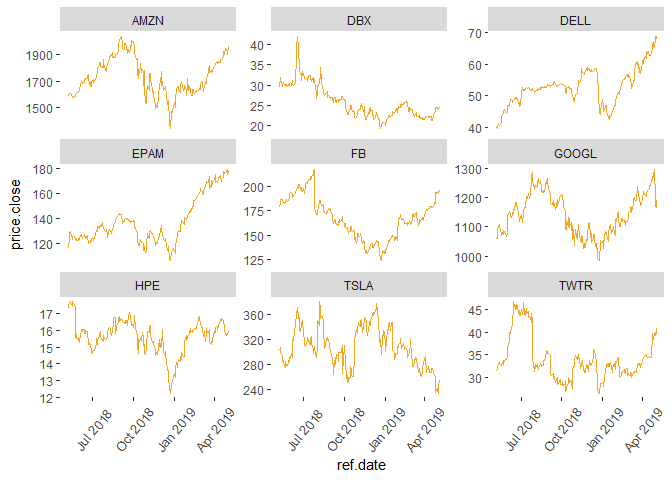

```r
p <- ggplot(l.out$df.tickers, aes(x = ref.date, y = price.close))
p <- p  + geom_line(color = "#F5A623") +
  facet_wrap(~ticker, scales = 'free_y') +
   theme(legend.background = element_rect(fill="transparent"),
         axis.text.x=element_text(angle=50, size=10, vjust=0.5),
        legend.key = element_rect(colour = "transparent", fill = "transparent"),
        plot.title = element_text(size=20, lineheight=.8, vjust=1, family ="Bauhaus 93", face='bold'),
        plot.background = element_rect(fill='transparent'), panel.background = element_rect(fill='transparent'))
print(p)
```

Adjust the data into proper time series format.

```r
ndays <- length(unique(l.out$df.tickers$ref.date))
ncomp <- length(unique(l.out$df.tickers$ticker))
data.prices<-setNames(data.frame(matrix(ncol = ncomp+1, nrow = ndays)), c(("date"), as.vector(unique(l.out$df.tickers$ticker))))
for(name in colnames(data.prices)[-1:ncomp + 1]){
  data.prices[name] <- subset(l.out$df.tickers, l.out$df.tickers$ticker == name)$price.close
}
data.prices$date <- unique(l.out$df.tickers$ref.date)
knitr::kable(head(data.prices, 10))
```

[output not shown]

```r
for (i in 2:ncol(data.prices)) {
  # Price time series of the i-th asset
  prices = data.prices[,i]

  # Price lagged by 1
  prices_prev = c(NA,prices[1:(length(prices)-1)])

  # Returns time series
  returns = (prices-prices_prev)/prices_prev

  # Replace the i-th column with returns
  data.prices[,i] = returns
}
# Remove the first row with NAs and the Date column
asset_returns = data.prices[2:nrow(data.prices),2:ncol(data.prices)]
knitr::kable(head(asset_returns, 10))
```

|  | TSLA | FB | AMZN | HPE | DBX | EPAM | TWTR | GOOGL | DELL |
| --- | --- | --- | --- | --- | --- | --- | --- | --- | --- |
| 2 | -0.0026422 | 0.0053380 | -0.0048433 | 0.0052023 | 0.0278817 | -0.0089020 | 0.0165975 | -0.0008212 | -0.0066216 |
| 3 | 0.0161606 | 0.0209032 | 0.0098029 | 0.0120760 | 0.0387033 | 0.0634730 | 0.0191522 | 0.0286796 | 0.0098598 |
| 4 | -0.0059639 | 0.0157122 | 0.0006716 | 0.0028409 | 0.0191083 | 0.0303249 | 0.0126309 | 0.0151706 | 0.0270902 |
| 5 | -0.0129827 | 0.0078694 | -0.0038344 | 0.0011331 | -0.0225000 | 0.0127255 | -0.0036507 | -0.0018906 | -0.0049538 |
| 6 | -0.0301933 | -0.0018718 | -0.0008547 | -0.0045274 | -0.0421996 | -0.0318378 | 0.0195420 | 0.0029183 | -0.0088806 |
| 7 | -0.0266809 | -0.0124303 | -0.0158723 | -0.0108016 | -0.0136849 | -0.0047774 | -0.0191674 | -0.0196367 | 0.0035298 |
| 8 | 0.0080935 | -0.0060764 | 0.0070807 | 0.0132183 | 0.0402708 | -0.0116009 | 0.0006107 | -0.0007190 | 0.0040584 |
| 9 | -0.0067719 | 0.0030568 | -0.0034777 | 0.0022689 | -0.0061809 | 0.0169176 | -0.0057979 | -0.0026104 | 0.0013474 |
| 10 | -0.0271315 | -0.0058772 | -0.0046720 | -0.0062253 | -0.0114566 | 0.0062088 | 0.0015347 | -0.0107467 | 0.0604144 |
| 11 | 0.0277075 | 0.0099081 | 0.0070441 | -0.0028473 | -0.0036424 | -0.0053793 | 0.0306466 | 0.0134344 | 0.0210633 |

```r
# Calculate portfolio returns
portfolio_returns = function(x) {
  port.returns = 0

  # Multiplication of the i-th asset by the i-th weight in "x"
  for (i in 1:length(x)) {
    port.returns = port.returns + asset_returns[,i] * x[i]
  }

  return (port.returns)
}
```

```r
# Using Sharpe ratio as an objective function
sharpe = function(x) {
  port.returns = portfolio_returns(x)

  return (mean(port.returns)/sqrt(var(port.returns)))
}
```

```r
# Penalty function keeps track of basic constraints for weights
penalty = function(x) {
 fine = 100 * abs((sum(x)-1))   # "sum x = 1" constraint

 for (i in 1:length(x)) {
  fine = fine +
     10 * max(c(0,x[i]-1))**2 +  # "x <= 1" constraint
     10 * max(c(0,-x[i]))**2     # "x >= 0" constraint
 }

 fine
}
# Function to be optimized
obj = function(x) {
  # We want the maximum Sharpe ratio, so we multiply it by
  # -1 to fit an optimization problem
   sharpe(x) - 100*penalty(x)
}
```

```r
library("GA")
ga_res = ga(
      type="real-valued",
      function(x){obj(x)},
      lower = rep(0, ncol(asset_returns)),
      upper = rep(1, ncol(asset_returns)),
      maxiter = 50000,
      # If the maximum fitness remains the same for 50
      # consecutive transactions, stop the algorithm
      run=50,
      monitor=TRUE
)
```

[output not shown]

[output cut: 98 more lines]

[output not shown]

```r
summary(ga_res)
```

```
## -- Genetic Algorithm -------------------
##
## GA settings:
## Type                  =  real-valued
## Population size       =  50
## Number of generations =  50000
## Elitism               =  2
## Crossover probability =  0.8
## Mutation probability  =  0.1
## Search domain =
##       x1 x2 x3 x4 x5 x6 x7 x8 x9
## lower  0  0  0  0  0  0  0  0  0
## upper  1  1  1  1  1  1  1  1  1
##
## GA results:
## Iterations             = 153
## Fitness function value = -0.05248247
## Solution =
##             x1        x2        x3        x4        x5         x6
## [1,] 0.1031368 0.1185398 0.1395613 0.1370534 0.1171052 0.06951518
##              x7        x8        x9
## [1,] 0.04942356 0.1256786 0.1399964
```

```r
# Save solution
sol <- as.vector(summary(ga_res)$solution)
cat("Weights are not exactly one due to rounding error: ", sum(sol))
```

```
## Weights are not exactly one due to rounding error:  1.00001
```

```r
returns <- sol[1] * asset_returns[,1] + sol[2] * asset_returns[,2]+sol[3] * asset_returns[,3]+sol[4] * asset_returns[,4]+sol[5] * asset_returns[,5]+sol[6] * asset_returns[,6]+sol[7] * asset_returns[,7]+sol[8] * asset_returns[,8]++sol[9] * asset_returns[,9]
```

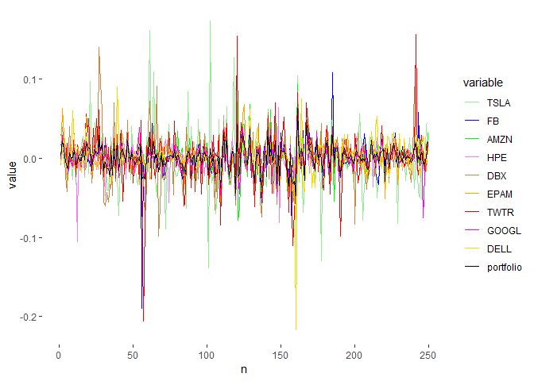

```r
asset_returns$portfolio <- returns
asset_returns$n <- c(1:(ndays-1))
library(reshape2)
d <- melt(asset_returns, id.vars="n")
# Everything on the same plot
ggplot(d, aes(n, value, col=variable)) + geom_line() + theme(plot.background = element_rect(fill='transparent'), panel.background = element_rect(fill='transparent'),  legend.key = element_rect(colour = "transparent", fill = "transparent")) + scale_colour_manual(values = c("lightgreen","blue", "green", "violet", "peru",'orange','red', "magenta", 'gold', "black"))
```

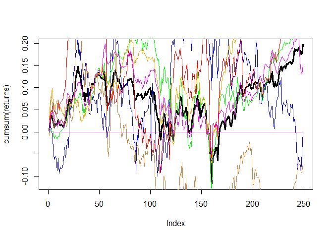

```r
plot(cumsum(returns),type="l",lwd=3)
lines(cumsum(asset_returns[,1]),col="blue")
lines(cumsum(asset_returns[,3]),col="green")
lines(cumprod(asset_returns[,4]),col="violet")
lines(cumsum(asset_returns[,5]),col="peru")
lines(cumsum(asset_returns[,6]),col="orange")
lines(cumsum(asset_returns[,7]),col="red")
lines(cumsum(asset_returns[,8]),col="magenta")
```

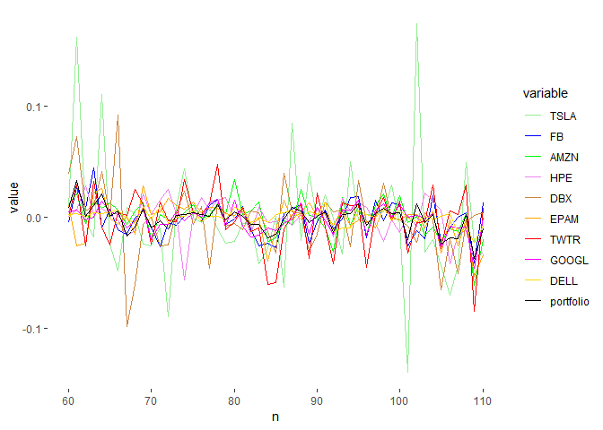

```r
# Close-up to 10 values
df10 <- asset_returns[60:110,]
d <- melt(df10, id.vars="n")
# Everything on the same plot
ggplot(d, aes(n, value, col=variable)) + geom_line() + theme(plot.background = element_rect(fill='transparent'), panel.background = element_rect(fill='transparent'),  legend.key = element_rect(colour = "transparent", fill = "transparent")) + scale_colour_manual(values = c("lightgreen","blue", "green", "violet", "peru",'orange','red', "magenta", 'gold', "black"))
```

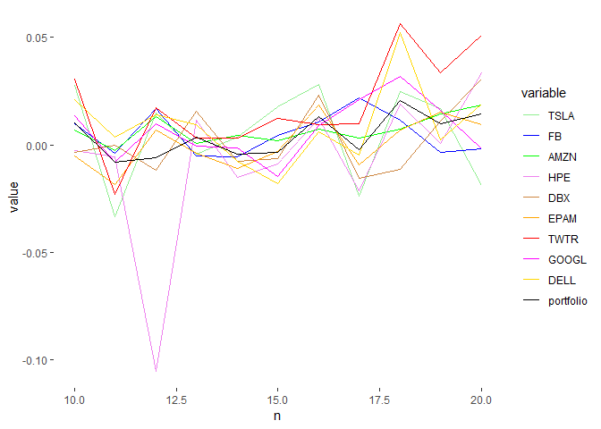

```r
# Close-up to 10 values
df10 <- asset_returns[10:20,]
d <- melt(df10, id.vars="n")
# Everything on the same plot
ggplot(d, aes(n, value, col=variable)) + geom_line() + theme(plot.background = element_rect(fill='transparent'), panel.background = element_rect(fill='transparent'),  legend.key = element_rect(colour = "transparent", fill = "transparent")) + scale_colour_manual(values = c("lightgreen","blue", "green", "violet", "peru",'orange','red', "magenta", 'gold', "black"))
```